# **Introduction to Python Project : FoodHub Data Analysis**

### **Problem Statement**

#### **Context**

The number of restaurants in New York is increasing day by day. Lots of students and busy professionals rely on those restaurants due to their hectic lifestyles. Online food delivery service is a great option for them. It provides them with good food from their favorite restaurants. A food aggregator company FoodHub offers access to multiple restaurants through a single smartphone app.

The app allows restaurants to receive a direct online order from a customer. The app assigns a delivery person from the company to pick up the order after it is confirmed by the restaurant. The delivery person then uses the map to reach the restaurant and waits for the food package. Once the food package is handed over to the delivery person, he/she confirms the pick-up in the app and travels to the customer's location to deliver the food. The delivery person confirms the drop-off in the app after delivering the food package to the customer. The customer can rate the order in the app. The food aggregator earns money by collecting a fixed margin on the delivery order from the restaurants.

#### **Objective**

The food aggregator company has stored the data of the different orders made by the registered customers in their online portal. They want to analyze the data to get a fair idea about the demand of different restaurants which will help them in enhancing their customer experience. Suppose you are hired as a Data Scientist in this company and the Data Science team has shared some of the key questions that need to be answered. Perform the data analysis to find answers to these questions that will help the company improve its business.

### **Data Dictionary**

The data includes various information related to a food order. A detailed data dictionary is provided below.

- *order_id*: Unique ID of the order
- *customer_id*: ID of the customer who ordered the food
- *restaurant_name*: Name of the restaurant
- *cuisine_type*: Cuisine ordered by the customer
- *cost_of_the_order*: Cost of the order
- *day_of_the_week*: Indicates whether the order is placed on a weekday or weekend (The weekday is from Monday to Friday and the weekend is Saturday and Sunday)
- *rating*: Rating given by the customer out of 5
- *food_preparation_time*: Time (in minutes) taken by the restaurant to prepare the food. This is calculated by taking the difference between the timestamps of the restaurant's order confirmation and the delivery person's pick-up confirmation.
- *delivery_time*: Time (in minutes) taken by the delivery person to deliver the food package. This is calculated by taking the difference between the timestamps of the delivery person's pick-up confirmation and drop-off information

### **Let us start by importing the required libraries**

```python
import numpy as np
import pandas as pd
import matplotlib.pyplot as plt
import seaborn as sns

import warnings
warnings.filterwarnings("ignore")
```

### **Understanding the structure of the data**

```python
# uncomment and run the following lines for Google Colab
from google.colab import drive
drive.mount('/content/drive')
orders = pd.read_csv('/content/drive/MyDrive/AI_Shared_Content/M1_W4_Project/foodhub_order.csv')
```

```python
# Write your code here to read the data
dataCopy = orders.copy()
```

```python
# Write your code here to view the first 5 rows
dataCopy.head()
```

|  | order_id | customer_id | restaurant_name | cuisine_type | cost_of_the_order | day_of_the_week | rating | food_preparation_time | delivery_time |
| --- | --- | --- | --- | --- | --- | --- | --- | --- | --- |
| 0 | 1477147 | 337525 | Hangawi | Korean | 30.75 | Weekend | Not given | 25 | 20 |
| 1 | 1477685 | 358141 | Blue Ribbon Sushi Izakaya | Japanese | 12.08 | Weekend | Not given | 25 | 23 |
| 2 | 1477070 | 66393 | Cafe Habana | Mexican | 12.23 | Weekday | 5 | 23 | 28 |
| 3 | 1477334 | 106968 | Blue Ribbon Fried Chicken | American | 29.20 | Weekend | 3 | 25 | 15 |
| 4 | 1478249 | 76942 | Dirty Bird to Go | American | 11.59 | Weekday | 4 | 25 | 24 |

### **Question 1:** How many rows and columns are present in the data? [0.5 mark]

```python
# Write your code here
dataCopy.shape
```

```
(1898, 9)
```

#### **Observations**:

Overall dataset contains 1898 Rows and 9 Columns.

### **Question 2:** What are the datatypes of the different columns in the dataset? (The info() function can be used) [0.5 mark]

```python
# Write your code here
dataCopy.info()
```

```
<class 'pandas.core.frame.DataFrame'>
RangeIndex: 1898 entries, 0 to 1897
Data columns (total 9 columns):
 #   Column                 Non-Null Count  Dtype
---  ------                 --------------  -----
 0   order_id               1898 non-null   int64
 1   customer_id            1898 non-null   int64
 2   restaurant_name        1898 non-null   object
 3   cuisine_type           1898 non-null   object
 4   cost_of_the_order      1898 non-null   float64
 5   day_of_the_week        1898 non-null   object
 6   rating                 1898 non-null   object
 7   food_preparation_time  1898 non-null   int64
 8   delivery_time          1898 non-null   int64
dtypes: float64(1), int64(4), object(4)
memory usage: 133.6+ KB
```

#### **Observations:**

1. Overall 1898 Rows and 9 Columns in the given dataset.
2. There are 4 integer columns(int64) - order_id, customer_id, food_preparation_time and delivery_time.
3. There is one float column(float64) - cost_of_the_order
4. There are 4 object columns(object) - restaurant_name, cuisine_type, day_of_the_week and rating

### **Question 3:** Are there any missing values in the data? If yes, treat them using an appropriate method. [1 mark]

```python
# Write your code here
print('Missing values in the given dataset : \n', dataCopy.isnull().sum())
print('_'*100)
print('Percentage of missing values in the given dataset : \n', dataCopy.isnull().sum()/len(dataCopy)*100)
print('_'*100)
print('Rating column data analysis : \n', dataCopy['rating'].value_counts())
```

```
Missing values in the given dataset :
 order_id                 0
customer_id              0
restaurant_name          0
cuisine_type             0
cost_of_the_order        0
day_of_the_week          0
rating                   0
food_preparation_time    0
delivery_time            0
dtype: int64
____________________________________________________________________________________________________
Percentage of missing values in the given dataset :
 order_id                 0.0
customer_id              0.0
restaurant_name          0.0
cuisine_type             0.0
cost_of_the_order        0.0
day_of_the_week          0.0
rating                   0.0
food_preparation_time    0.0
delivery_time            0.0
dtype: float64
____________________________________________________________________________________________________
Rating column data analysis :
 rating
Not given    736
5            588
4            386
3            188
Name: count, dtype: int64
```

#### **Observations:**

1. No columns having null values and also all columns are marked as non-null, so null is not possible in the records.
2. Rating column having some missing values with the value "Not given".
3. Different methods of treating missing values - Mean, Median and Mode.
4. we will handle the 'Not given' value with some meaningful value by imputing data to make it usable.

```python
dataCopy['rating'] = dataCopy['rating'].replace('Not given', np.nan)

print('Rating value count after replacing Not given to NAN : \n', dataCopy['rating'].value_counts())
print('Rating column NAN value count after replacement of Not given value to NAN : ', dataCopy['rating'].isnull().sum())
print('_'*100)
dataCopy['rating'] = dataCopy['rating'].astype('Int64')
print('Rating column counts including NAN : ', dataCopy['rating'].value_counts(dropna=False))
print('_'*100)
dataCopy.info()
print('_'*100)
print('Overall analysis of the given foodhub dataset')
print(dataCopy.describe().T)
print('_'*100)
print('Average / Mean of Rating : ', dataCopy['rating'].mean())
print('Median of Rating : ', dataCopy['rating'].median())
print('Mode of Rating : ', dataCopy['rating'].mode())
print('_'*100)

## Imputing missing data
dataCopy['updated_rating'] = dataCopy['rating'].copy().fillna(5)
print('Updated rating column counts including NAN : ', dataCopy['updated_rating'].value_counts(dropna=False))
print('_'*100)
print(dataCopy[['rating', 'updated_rating']].head(10))
print('_'*100)
```

```
Rating value count after replacing Not given to NAN :
 rating
5    588
4    386
3    188
Name: count, dtype: int64
Rating column NAN value count after replacement of Not given value to NAN :  736
____________________________________________________________________________________________________
Rating column counts including NAN :  rating
<NA>    736
5       588
4       386
3       188
Name: count, dtype: Int64
____________________________________________________________________________________________________
<class 'pandas.core.frame.DataFrame'>
RangeIndex: 1898 entries, 0 to 1897
Data columns (total 9 columns):
 #   Column                 Non-Null Count  Dtype
---  ------                 --------------  -----
 0   order_id               1898 non-null   int64
 1   customer_id            1898 non-null   int64
 2   restaurant_name        1898 non-null   object
 3   cuisine_type           1898 non-null   object
 4   cost_of_the_order      1898 non-null   float64
 5   day_of_the_week        1898 non-null   object
 6   rating                 1162 non-null   Int64
 7   food_preparation_time  1898 non-null   int64
 8   delivery_time          1898 non-null   int64
dtypes: Int64(1), float64(1), int64(4), object(3)
memory usage: 135.4+ KB
____________________________________________________________________________________________________
Overall analysis of the given foodhub dataset
                        count           mean            std        min  \
order_id               1898.0      1477495.5     548.049724  1476547.0
customer_id            1898.0  171168.478398  113698.139743     1311.0
cost_of_the_order      1898.0      16.498851       7.483812       4.47
rating                 1162.0       4.344234       0.741478        3.0
food_preparation_time  1898.0       27.37197       4.632481       20.0
delivery_time          1898.0      24.161749       4.972637       15.0
```

[output cut: 17 more lines]

```
3     188
Name: count, dtype: Int64
____________________________________________________________________________________________________
   rating  updated_rating
0    <NA>               5
1    <NA>               5
2       5               5
3       3               3
4       4               4
5       3               3
6    <NA>               5
7       3               3
8       5               5
9       5               5
____________________________________________________________________________________________________
```

#### **Observations:**

1. rating column having 'Not given' record
2. while trying to convert the column to int64, we got the error 'cannot convert float NaN to integer'
3. we converted rating column to Int64 datatype (This will handle both integers and missing values NAN)
4. we are imputing rating based on the analysis of entire rating dataset.
5. Rating analysis : Mean is 4.344234 and Median is 5.0 and Mode is 0 - 5
6. Most of rating data is highly skewed between 4 and 5.
7. Rating column is not related with other columns.
8. we decided to imputting with 5 value in the missing rating records in a new rating column named 'updated_rating'

### **Question 4:** Check the statistical summary of the data. What is the minimum, average, and maximum time it takes for food to be prepared once an order is placed? [2 marks]

```python
# Write your code here
dataCopy.describe().T
```

|  | count | mean | std | min | 25% | 50% | 75% | max |
| --- | --- | --- | --- | --- | --- | --- | --- | --- |
| order_id | 1898.0 | 1477495.5 | 548.049724 | 1476547.0 | 1477021.25 | 1477495.5 | 1477969.75 | 1478444.0 |
| customer_id | 1898.0 | 171168.478398 | 113698.139743 | 1311.0 | 77787.75 | 128600.0 | 270525.0 | 405334.0 |
| cost_of_the_order | 1898.0 | 16.498851 | 7.483812 | 4.47 | 12.08 | 14.14 | 22.2975 | 35.41 |
| rating | 1162.0 | 4.344234 | 0.741478 | 3.0 | 4.0 | 5.0 | 5.0 | 5.0 |
| food_preparation_time | 1898.0 | 27.37197 | 4.632481 | 20.0 | 23.0 | 27.0 | 31.0 | 35.0 |
| delivery_time | 1898.0 | 24.161749 | 4.972637 | 15.0 | 20.0 | 25.0 | 28.0 | 33.0 |
| updated_rating | 1898.0 | 4.598525 | 0.662289 | 3.0 | 4.0 | 5.0 | 5.0 | 5.0 |

#### **Observations:**

we analysed entire given dataset with the help of describe method.

Summary on food preparation time after the order is placed

1. Minimum time - 20.0 Mins
2. Average time - 27.37 Mins
3. Maximum time - 35.0 Mins

### **Question 5:** How many orders are not rated? [1 mark]

```python
# Write the code here
print('Rating column counts including NAN : ', dataCopy['rating'].value_counts(dropna=False))
print('_'*100)
print('Rating null counts : ', dataCopy['rating'].isnull().sum())
print('_'*100)
print('Updated rating column counts including NAN : ', dataCopy['updated_rating'].value_counts(dropna=False))
print('_'*100)
print('Updated rating null counts : ', dataCopy['updated_rating'].isnull().sum())
print('_'*100)
```

```
Rating column counts including NAN :  rating
<NA>    736
5       588
4       386
3       188
Name: count, dtype: Int64
____________________________________________________________________________________________________
Rating null counts :  736
____________________________________________________________________________________________________
Updated rating column counts including NAN :  updated_rating
5    1324
4     386
3     188
Name: count, dtype: Int64
____________________________________________________________________________________________________
Updated rating null counts :  0
____________________________________________________________________________________________________
```

### Exploratory Data Analysis (EDA)

### **Question 6:** Explore all the variables and provide observations on their distributions. (Generally, histograms, boxplots, countplots, etc. are used for univariate exploration.) [9 marks]

We will do the univariate analysis on the below individual column datas.

**Numerical columns**

1. customer_id
2. cost_of_the_order
3. rating
4. food_preparation_time
5. delivery_time

**Other columns**

1. restaurant_name
2. cuisine_type
3. day_of_the_week

```
Total number of unique customers :  1200
Mean order by customer :  1.5816666666666668
Top 5 customers by order count
customer_id
52832     13
47440     10
83287      9
250494     8
259341     7
Name: count, dtype: int64
Total number of orders from top 5 customers :  47
Bottom 5 customers by order count
customer_id
143926    1
89574     1
157711    1
66393     1
358141    1
Name: count, dtype: int64
Total number of orders from bottom 5 customers :  5
```

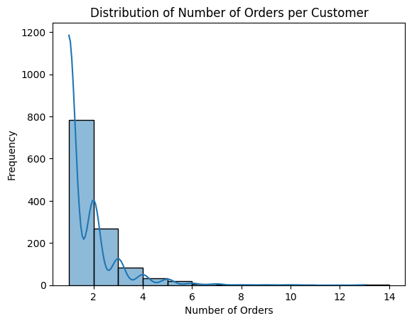

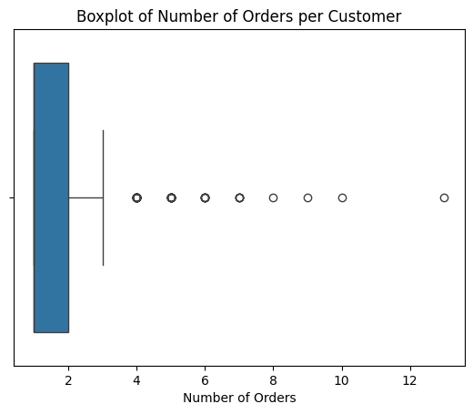

```python
#Univariate 1 - Observation on customer orders
print('Total number of unique customers : ', (dataCopy['customer_id']).nunique())

print('Mean order by customer : ', (dataCopy['customer_id'].value_counts()).mean())

top5Customers = dataCopy['customer_id'].value_counts().head(5)
print('Top 5 customers by order count')
print(top5Customers)

print('Total number of orders from top 5 customers : ', top5Customers.sum())

bottom5Customers = dataCopy['customer_id'].value_counts().tail(5)
print('Bottom 5 customers by order count')
print(bottom5Customers)

print('Total number of orders from bottom 5 customers : ', bottom5Customers.sum())

# Histogram of customers with order counts
customer_order_counts = dataCopy['customer_id'].value_counts()
bins = [i for i in range(1,15,1)]
sns.histplot(customer_order_counts, bins=bins, kde=True)
plt.xlabel('Number of Orders')
plt.ylabel('Frequency')
plt.title('Distribution of Number of Orders per Customer')
plt.show()
print("-"*60)

# Boxplot of customers with order counts
sns.boxplot(x=customer_order_counts)
plt.xlabel('Number of Orders')
plt.title('Boxplot of Number of Orders per Customer')
plt.show()
```

#### **Observations:**

Univariate 1 (Observation on customers)

```
Mean Average cost of the order :  16.498851422550054
------------------------------------------------------------
```

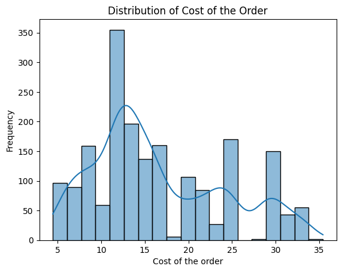

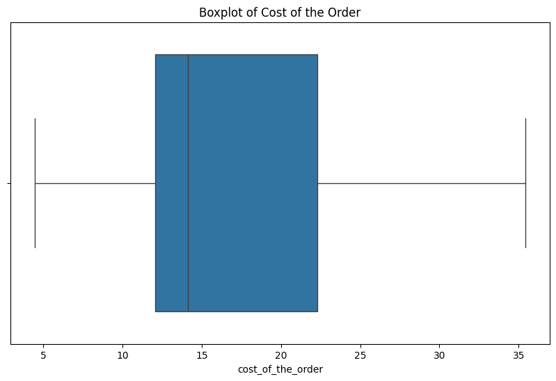

```python
#Univariate 2 - Observation on cost of the order

print('Mean Average cost of the order : ', dataCopy['cost_of_the_order'].mean())
print("-"*60)

# Histogram of cost of the order
sns.histplot(dataCopy['cost_of_the_order'], kde=True)
plt.xlabel('Cost of the order')
plt.ylabel('Frequency')
plt.title('Distribution of Cost of the Order')
plt.show()
print("-"*60)

# Boxplot of cost of the order
plt.figure(figsize=(10, 6))
sns.boxplot(x=dataCopy['cost_of_the_order'])
plt.title('Boxplot of Cost of the Order')
plt.show()
```

### **Observations** :

1. Based on the histogram, distribution of cost is slightly skewed to the right.
2. There are no outliers in either side.
3. Average mean cost of the order is $16.5
4. Minimum cost of the order is $4
5. maximum cost is around $35

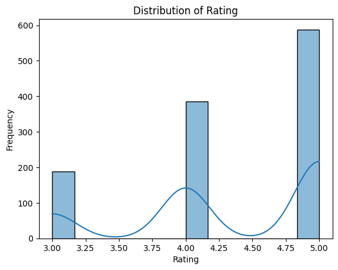

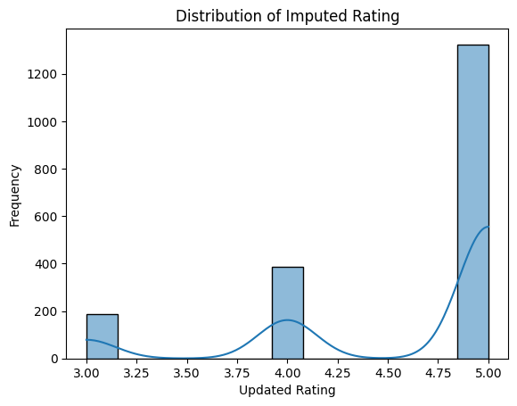

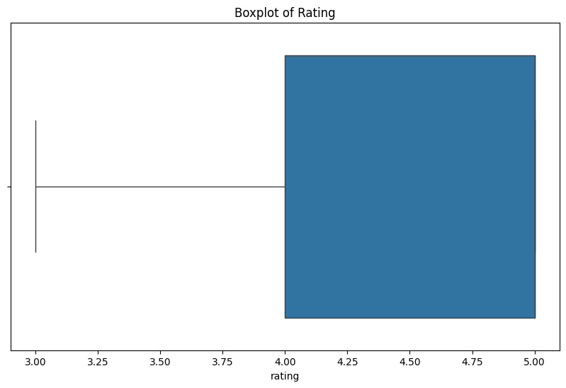

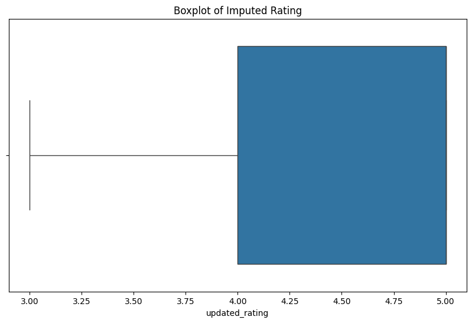

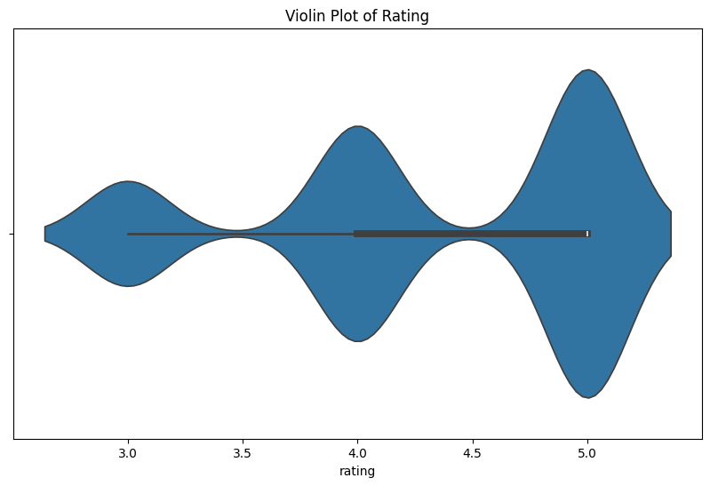

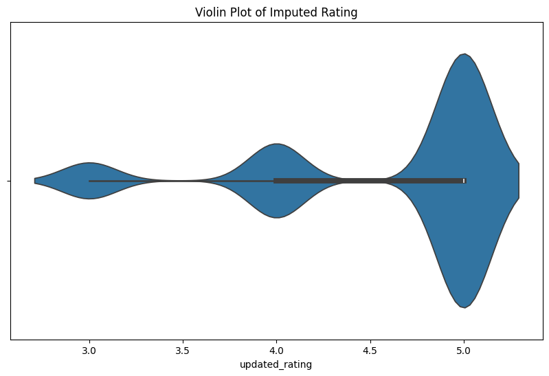

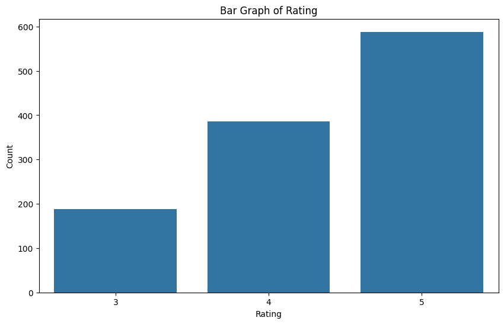

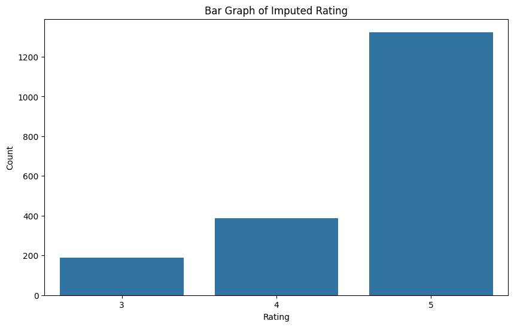

```python
#Univariate 3 - Observation on rating
# Histogram of actual rating
sns.histplot(dataCopy['rating'], kde=True)
plt.xlabel('Rating')
plt.ylabel('Frequency')
plt.title('Distribution of Rating')
plt.show()

print("-"*60)

# Histogram of updated rating
sns.histplot(dataCopy['updated_rating'], kde=True)
plt.xlabel('Updated Rating')
plt.ylabel('Frequency')
plt.title('Distribution of Imputed Rating')
plt.show()

print("-"*60)

# Boxplot of actual rating
plt.figure(figsize=(10, 6))
sns.boxplot(x=dataCopy['rating'])
plt.title('Boxplot of Rating')
plt.show()

print("-"*60)

# Boxplot of updated rating
plt.figure(figsize=(10, 6))
sns.boxplot(x=dataCopy['updated_rating'])
plt.title('Boxplot of Imputed Rating')
plt.show()

# Violin Plot of actual rating
plt.figure(figsize=(10, 6))
sns.violinplot(x=dataCopy['rating'])
plt.title('Violin Plot of Rating')
plt.show()

print("-"*60)

# Violin Plot of updated rating
plt.figure(figsize=(10, 6))
sns.violinplot(x=dataCopy['updated_rating'])
plt.title('Violin Plot of Imputed Rating')
plt.show()

print("-"*60)

# Bar graph of actual rating
rating_counts = dataCopy['rating'].value_counts()
plt.figure(figsize=(10, 6))
sns.barplot(x=rating_counts.index, y=rating_counts.values)
plt.xlabel('Rating')
plt.ylabel('Count')
plt.title('Bar Graph of Rating')
plt.show()

print("-"*60)

# Bar graph of updated rating
rating_counts = dataCopy['updated_rating'].value_counts()
plt.figure(figsize=(10, 6))
sns.barplot(x=rating_counts.index, y=rating_counts.values)
plt.xlabel('Rating')
plt.ylabel('Count')
plt.title('Bar Graph of Imputed Rating')
plt.show()
```

### **Observations** :

**Univariate 3 (Observation on ratings)**

1. We analysed with both (acutal and imputed) rating data.
2. Rating data is left skewed.
3. There are low number of orders are rated as 3
4. There are high number of orders are rated as 5
5. There is no ratings with 1 and 2, All ratings are ranging from 3 to 5.

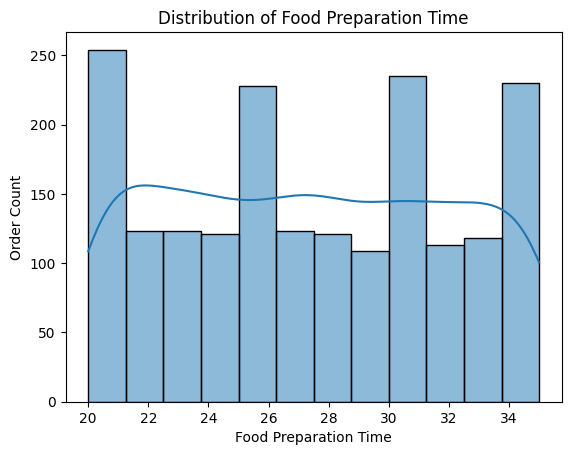

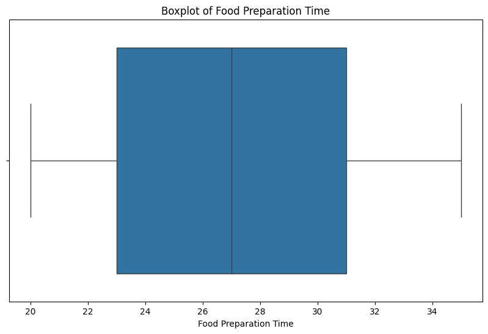

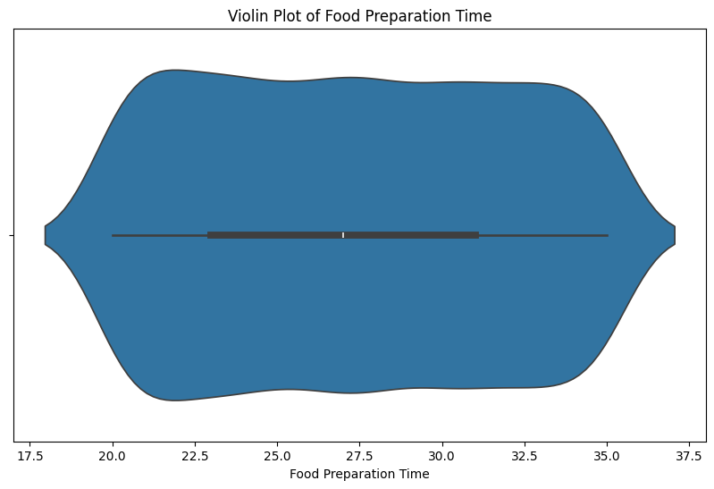

```python
#Univariate 4 - Observation on food preparation time

# Histogram on food preparation time
sns.histplot(dataCopy['food_preparation_time'], kde=True)
plt.xlabel('Food Preparation Time')
plt.ylabel('Order Count')
plt.title('Distribution of Food Preparation Time')
plt.show()

print("-"*60)

# Boxplot on food preparation time
plt.figure(figsize=(10, 6))
sns.boxplot(x=dataCopy['food_preparation_time'])
plt.xlabel('Food Preparation Time')
plt.title('Boxplot of Food Preparation Time')
plt.show()

print("-"*60)

# Violin Plot on food preparation time
plt.figure(figsize=(10, 6))
sns.violinplot(x=dataCopy['food_preparation_time'])
plt.xlabel('Food Preparation Time')
plt.title('Violin Plot of Food Preparation Time')
plt.show()

print("-"*60)
```

### **Observations** :

**Univariate 4 (Observation on food preparation time)**

1. Overall distribution of food preparation time is uniform
2. No outliers on both sides (based on boxplot analysis)
3. Food preparation time is lies between 20 to 35 mins.
4. Every minute atleast 100 orders are in preparation.

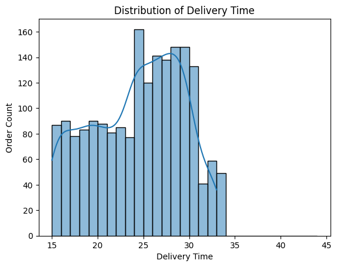

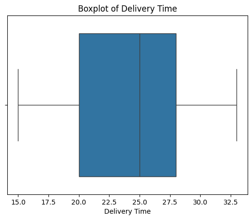

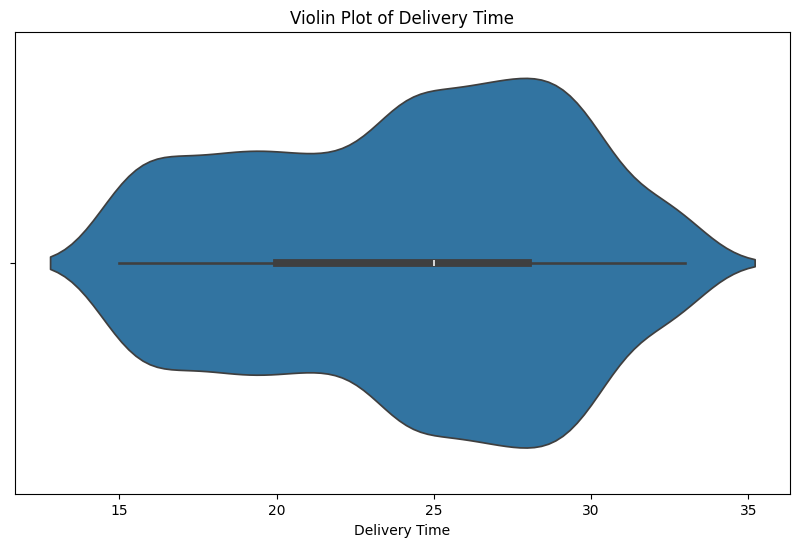

```python
#Univariate 5 - Observation on delivery time

# Histogram on delivery time
bins = [i for i in range(15,45,1)]
sns.histplot(dataCopy['delivery_time'], bins=bins, kde=True)
plt.xlabel('Delivery Time')
plt.ylabel('Order Count')
plt.title('Distribution of Delivery Time')
plt.show()

print("-"*60)

# Boxplot on delivery time
sns.boxplot(x=dataCopy['delivery_time'])
plt.xlabel('Delivery Time')
plt.title('Boxplot of Delivery Time')
plt.show()

print("-"*60)

# Violin Plot on delivery time
plt.figure(figsize=(10, 6))
sns.violinplot(x=dataCopy['delivery_time'])
plt.xlabel('Delivery Time')
plt.title('Violin Plot of Delivery Time')
plt.show()

print("-"*60)
```

### **Observations** :

**Univariate 5 (Observation on delivery time)**

1. Based on histogram, Distribution of delivery time is left skewed
2. There no outliers based on the boxplot
3. Average mean time is around 25 minutes based on the boxplot
4. More than 50% of orders are delivered in 25 mins.

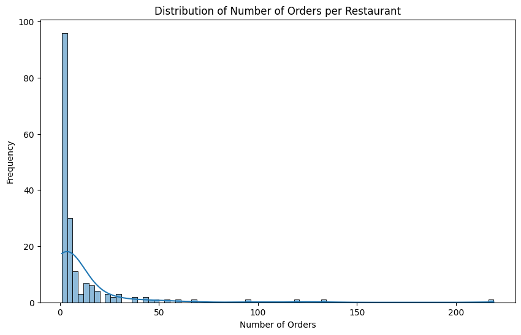

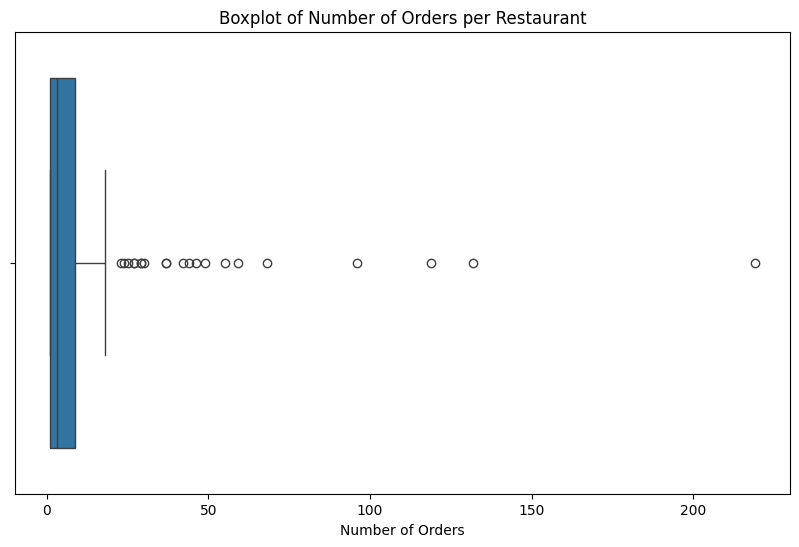

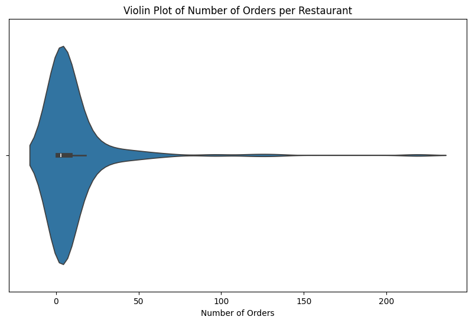

```
------------------------------------------------------------
Total number of restaurants by name :  178
------------------------------------------------------------
Top 5 restaurants by order count
restaurant_name
Shake Shack                  219
The Meatball Shop            132
Blue Ribbon Sushi            119
Blue Ribbon Fried Chicken     96
Parm                          68
Name: count, dtype: int64
------------------------------------------------------------
Bottom 5 restaurants by order count
restaurant_name
Rye House           1
Hiroko's Place      1
Frank Restaurant    1
Sarabeth's West     1
'wichcraft          1
Name: count, dtype: int64
------------------------------------------------------------
Total number of orders from top 5 restaurants :  634
Total number of orders from bottom 5 restaurants :  5
```

```python
#Univariate 6 - Observation on restaurant name

# Histogram on restaurant name
restaurant_counts = dataCopy['restaurant_name'].value_counts()
plt.figure(figsize=(10, 6))
sns.histplot(restaurant_counts, kde=True)
plt.xlabel('Number of Orders')
plt.ylabel('Frequency')
plt.title('Distribution of Number of Orders per Restaurant')
plt.show()

print("-"*60)

# Boxplot on restaurant name
plt.figure(figsize=(10, 6))
sns.boxplot(x=restaurant_counts)
plt.xlabel('Number of Orders')
plt.title('Boxplot of Number of Orders per Restaurant')
plt.show()

print("-"*60)

# Violin plot of Restaurant name
plt.figure(figsize=(10, 6))
sns.violinplot(x=restaurant_counts)
plt.xlabel('Number of Orders')
plt.title('Violin Plot of Number of Orders per Restaurant')
plt.show()

print("-"*60)

print("Total number of restaurants by name : ", len(restaurant_counts))

print("-"*60)

print('Top 5 restaurants by order count')
print(restaurant_counts.head(5))

print("-"*60)

print('Bottom 5 restaurants by order count')
print(restaurant_counts.tail(5))

print("-"*60)

print('Total number of orders from top 5 restaurants : ', restaurant_counts.head(5).sum())

print('Total number of orders from bottom 5 restaurants : ', restaurant_counts.tail(5).sum())
```

### **Observations** :

**Univariate 6 (Observation on restaurant name)**

1. There are 178 restaurants available
2. order distribution accross restaurants are right skewed.
3. There are outliers available based on boxplot
4. Top restaurant (Shake Shack) received 219 orders
5. Most of the restaurants received around 1 order.
6. Top 5 restaurants received 634 orders.
7. Bottom 5 restaurants received only 5 orders (each got 1 order)

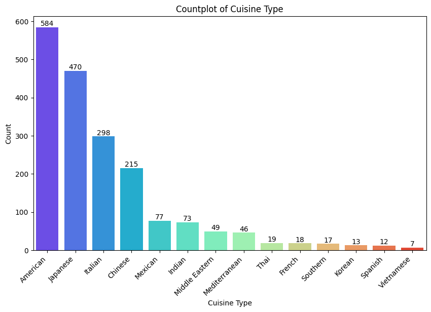

```python
#Univariate 7 - Observation on cuisine type

# Countplot based on cuisine type
plt.figure(figsize=(10, 6))
cp = sns.countplot(data=dataCopy, x='cuisine_type', order = dataCopy['cuisine_type'].value_counts().index, palette='rainbow')
cp.set_xticklabels(cp.get_xticklabels(), rotation=45, horizontalalignment='right')
plt.xlabel('Cuisine Type')
plt.ylabel('Count')
plt.title('Countplot of Cuisine Type')

# Add counts on top of each bar
for container in cp.containers:
    cp.bar_label(container, fmt='%d')

plt.show()

print("-"*60)
```

### **Observations** :

**Univariate 7 (Observation on cuisine type)**

1. American cuisine received maximum number of orders (order count is 584)
2. Most of the orders are received for American, Japanese, Italian and Chinese cuisines.
3. Other cuiseine types receive less number of orders.
4. Vietnamese is the least ordered cuisine type (order count is 7)

```python
#Univariate 8 - Observation on day of the week
```

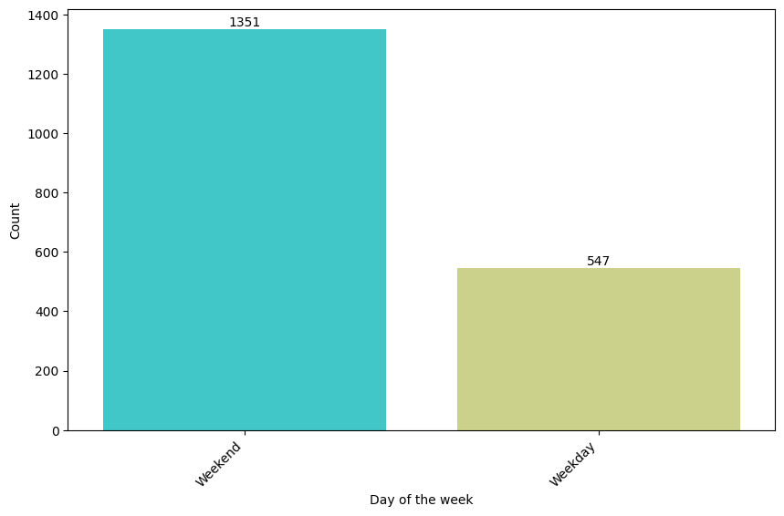

```
------------------------------------------------------------
Total number of orders in weekends :  1351
Total number of orders in weekdays :  547
------------------------------------------------------------
```

```python
# Countplot on day of the week by order
plt.figure(figsize=(10, 6))
cp = sns.countplot(data=dataCopy, x='day_of_the_week', order = dataCopy['day_of_the_week'].value_counts().index, palette='rainbow')
cp.set_xticklabels(cp.get_xticklabels(), rotation=45, horizontalalignment='right')
plt.xlabel('Day of the week')
plt.ylabel('Count')

print("-"*60)

# Add counts on top of each bar
for container in cp.containers:
    cp.bar_label(container, fmt='%d')

plt.show()

print("-"*60)

print('Total number of orders in weekends : ', (dataCopy['day_of_the_week'] == 'Weekend').sum())
print('Total number of orders in weekdays : ', (dataCopy['day_of_the_week'] == 'Weekday').sum())

print("-"*60)
```

### **Observations** :

**Univariate 8 (Observation on day of the week)**

1. Weekends receive most orders compared with weekdays.
2. Weekend received 1351 orders, whereas weekday received only 547 orders.

### **Question 7**: Which are the top 5 restaurants in terms of the number of orders received? [1 mark]

```python
# Write the code here
dataCopy['restaurant_name'].value_counts().head(5)
```

| restaurant_name | count |
| --- | --- |
| Shake Shack | 219 |
| The Meatball Shop | 132 |
| Blue Ribbon Sushi | 119 |
| Blue Ribbon Fried Chicken | 96 |
| Parm | 68 |

**dtype:** int64

#### **Observations:**

Based on the number of orders received, following are the list of top 5 restaurants.

Shake Shack - 219

The Meatball Shop - 132

Blue Ribbon Sushi - 119

Blue Ribbon Fried Chicken - 96

Parm - 68

### **Question 8**: Which is the most popular cuisine on weekends? [1 mark]

```python
# Write the code here
dataCopy[dataCopy['day_of_the_week'] == 'Weekend']['cuisine_type'].value_counts().head(1)
```

| cuisine_type | count |
| --- | --- |
| American | 415 |

**dtype:** int64

#### **Observations:**

1. American cuisine is the most popular cuisine on weekends.

### **Question 9**: What percentage of the orders cost more than 20 dollars? [2 marks]

```python
# Write the code here
totalOrderCount = len(dataCopy)
print('Total order count : ', totalOrderCount)
filteredOrderTotalCost = (dataCopy['cost_of_the_order'] > 20).sum()
print('Total order cost (orders above 20 dollars) : ', filteredOrderTotalCost)
resultPercentage = (filteredOrderTotalCost/totalOrderCount)*100
print('Percentage of orders cost more than 20 dollars : ', resultPercentage)
```

```
Total order count :  1898
Total order cost (orders above 20 dollars) :  555
Percentage of orders cost more than 20 dollars :  29.24130663856691
```

#### **Observations:**

There are 29.24% percentage of orders are cost more than 20 dollars.

### **Question 10**: What is the mean order delivery time? [1 mark]

```python
# Write the code here
print('Mean order delivery time : ', dataCopy['delivery_time'].mean())
```

```
Mean order delivery time :  24.161749209694417
```

#### **Observations:**

The mean order delivery time is approximately 24 mins (exactly 24.16 Mins)

### **Question 11:** The company has decided to give 20% discount vouchers to the top 3 most frequent customers. Find the IDs of these customers and the number of orders they placed. [1 mark]

```python
# Write the code here
frequentCustomers = dataCopy['customer_id'].value_counts().head(3)
print('Top 3 most frequent customers : \n', frequentCustomers)
```

```
Top 3 most frequent customers :
 customer_id
52832    13
47440    10
83287     9
Name: count, dtype: int64
```

#### **Observations:**

Below customers are ordered mostly and they are considered for 20% discount vouchers.

**customer_id with order count**

52832 - 13

47440 - 10

83287 - 9

### **Question 12**: Perform a multivariate analysis to explore relationships between the important variables in the dataset. (It is a good idea to explore relations between numerical variables as well as relations between numerical and categorical variables) [10 marks]

**Multivariate Analysis**

We will do multivariate analysis with the following variables

```
  1. Customer and cost_of_the_order
  2. Customer and cuisine_type and cost_of_the_order
  3. Cuisine_type and cost_of_the_order
  4. Cuisine_type and food_preparation_time and delivery_time
  5. Top restaurants and total time by day of the week
  6. Restaurant_name and total_cost_of_the_order
  7. Average of total_time and day_of_the_week
  8. Rating, Restaurant and Cuisine_type
  9. Correlation matrix
  10. Day_of_the_week and rating
```

```
count    1200.000000
mean       16.456487
std         6.591341
min         4.750000
25%        12.130000
50%        15.040000
75%        20.785000
max        33.320000
Name: avg_order_cost, dtype: float64
____________________________________________________________
```

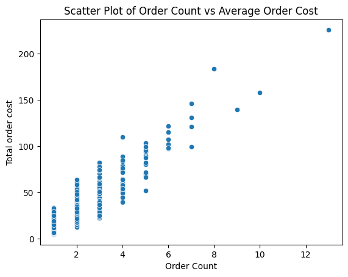

```
____________________________________________________________
____________________________________________________________
```

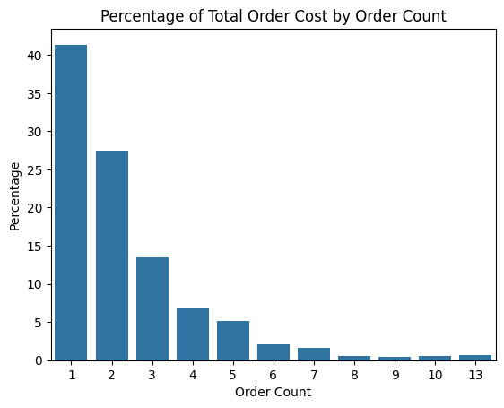

```python
# Multivariate Analysis 1 - Customer and cost_of_the_order

customer_order_data = dataCopy.groupby('customer_id')['cost_of_the_order'].agg(['count', 'mean', 'sum'])
customer_order_data.rename(columns={'count': 'order_count', 'mean': 'avg_order_cost', 'sum': 'total_order_cost'}, inplace=True)

print(customer_order_data['avg_order_cost'].describe().T)

print('_'*60)

sns.scatterplot(customer_order_data, x=customer_order_data['order_count'], y=customer_order_data['total_order_cost'])
plt.xlabel('Order Count')
plt.ylabel('Total order cost')
plt.title('Scatter Plot of Order Count vs Average Order Cost')
plt.show()

print('_'*60)

orders_cost_by_count = customer_order_data.groupby('order_count', as_index=False)['total_order_cost'].sum()
orders_cost_by_count['percentage'] = (orders_cost_by_count['total_order_cost'] / orders_cost_by_count['total_order_cost'].sum()) * 100
print('_'*60)

sns.barplot(data=orders_cost_by_count, x='order_count', y='percentage', legend=False)
plt.xlabel('Order Count')
plt.ylabel('Percentage')
plt.title('Percentage of Total Order Cost by Order Count')
plt.show()
```

### **Observations**:

Multivariate analysis observation on Customer and cost_of_the_order

1. Overall 1200 unique customers
2. Most of the orders are from repeated customers (Around 59%)
3. Scatter plot showing that the outlier customers are spending high.
4. One customer spent $225 on 13 orders.

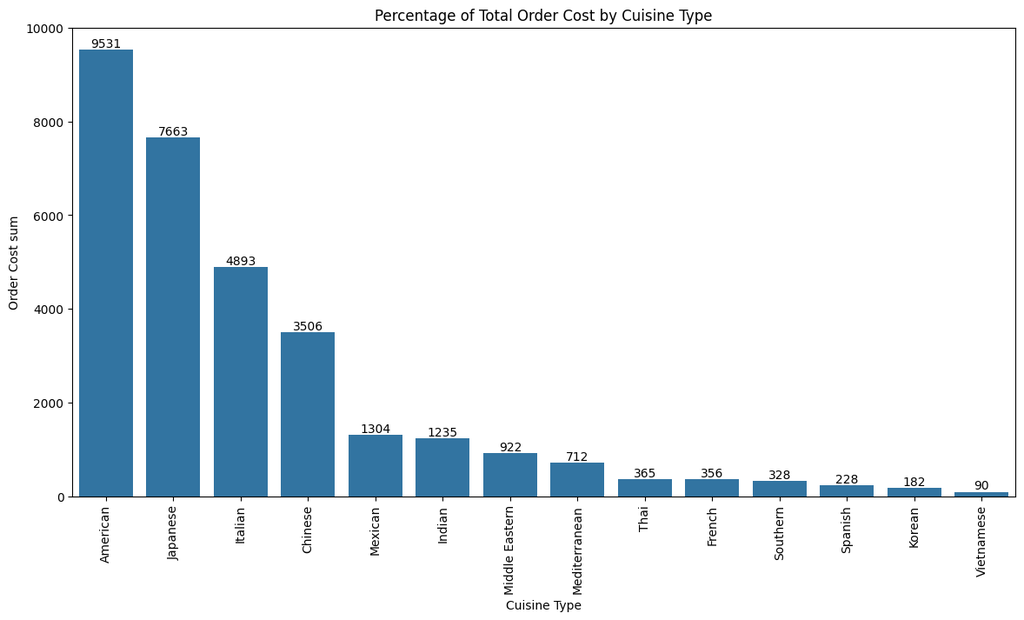

```python
# Multivariate Analysis 2 - Customer and cuisine_type and cost_of_the_order

customer_spend_on_cuisine = dataCopy.groupby(['customer_id', 'cuisine_type'])['cost_of_the_order'].agg(['count', 'mean', 'sum']).reset_index()
group_by_cuisine = customer_spend_on_cuisine.groupby('cuisine_type', as_index=False)['sum'].sum().sort_values(by='sum', ascending=False)
group_by_cuisine['percentage'] = (group_by_cuisine['sum'] / group_by_cuisine['sum'].sum()) * 100

plt.figure(figsize=(14, 7)) # Increased figure size for better label spacing
ax = sns.barplot(data=group_by_cuisine, x='cuisine_type', y='sum', legend=False)
plt.xlabel('Cuisine Type')
plt.xticks(rotation=90)
plt.ylabel('Order Cost sum')
plt.title('Percentage of Total Order Cost by Cuisine Type')

# Add total sum on top of each bar
for container in ax.containers:
    ax.bar_label(container, fmt='%.0f') # Format to whole numbers to avoid overlap

plt.show()
```

### **Observations**:

Multivariate analysis observation on Customer and cuisine_type and cost_of_the_order

1. American cuisine received highest order cost of $9531
2. Vietnamese cuisine received lowest order cost of $90
3. American, Japanese, Italian and Chinese cuisines are majorly liked by most of the customers based on order count and total order cost.

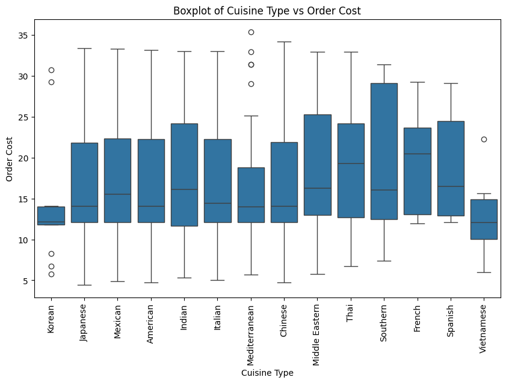

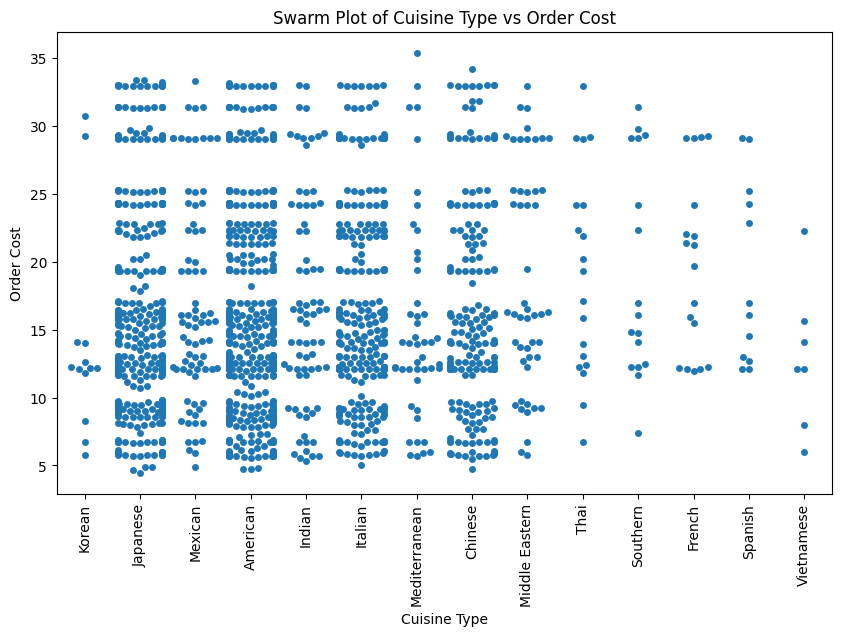

```python
# Multivariate Analysis 3 - Cuisine_type and cost_of_the_order

plt.figure(figsize=(10, 6))
sns.boxplot(data=dataCopy, x='cuisine_type', y='cost_of_the_order')
plt.xlabel('Cuisine Type')
plt.ylabel('Order Cost')
plt.title('Boxplot of Cuisine Type vs Order Cost')
plt.xticks(rotation=90)
plt.show()

print("-"*60)

plt.figure(figsize=(10, 6))
sns.swarmplot(data=dataCopy, x='cuisine_type', y='cost_of_the_order')
plt.xlabel('Cuisine Type')
plt.ylabel('Order Cost')
plt.title('Swarm Plot of Cuisine Type vs Order Cost')
plt.xticks(rotation=90)
plt.show()
```

### **Observations**:

Multivariate analysis observation on Cuisine_type and cost_of_the_order

1. Based on boxplot, Average mean cost of the order is high in French and Thai cuisines (around $20)
2. Based on scatter plot, its evident that the average cost of 4 top cuisines (American, Japanese, Italian and Chinese) are scattered around $15.

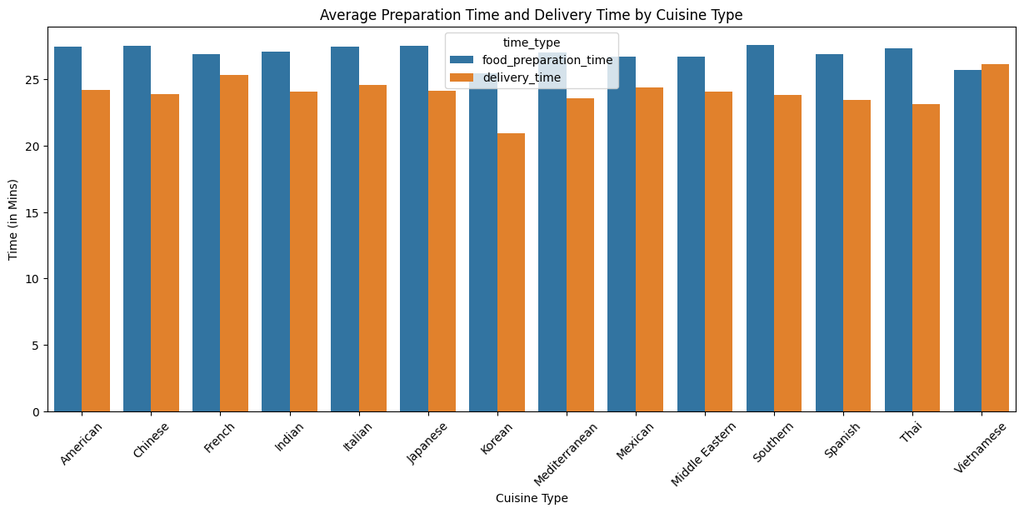

```python
# Multivariate Analysis 4 - Cuisine_type and food_preparation_time and delivery_time

dataCopyAvgTime = dataCopy.groupby('cuisine_type')[['food_preparation_time', 'delivery_time']].mean().reset_index()
meltedData = dataCopyAvgTime.melt(id_vars='cuisine_type', var_name='time_type', value_name='time', value_vars=['food_preparation_time', 'delivery_time'])
plt.figure(figsize=(15, 6))
sns.barplot(data=meltedData, x='cuisine_type', y='time', hue='time_type')
plt.xlabel('Cuisine Type')
plt.ylabel('Time (in Mins)')
plt.xticks(rotation=45)
plt.title('Average Preparation Time and Delivery Time by Cuisine Type')
```

### **Observations**:

Multivariate analysis observation on Cuisine_type and food_preparation_time and delivery_time

1. Other than Vietnamese cuisine, all the other cuisines delivery time is lesser than the food preparation time.
2. Korean cuisine is having more time difference between food preparation and delivery time.
3. Almost all the cuisines are following the same preparation and delivery time trend.

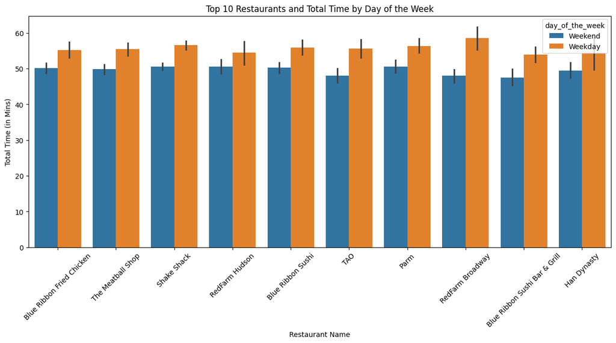

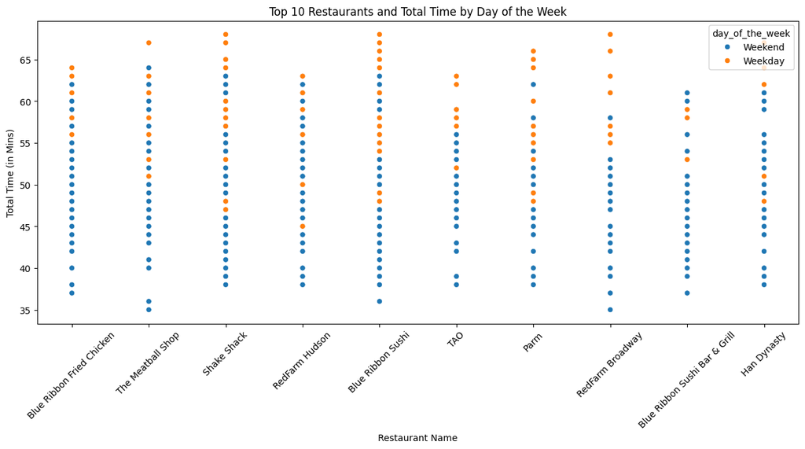

```python
# Multivariate Analysis 5 - Top restaurants and total time by day of the week
dataCopy['total_time'] = dataCopy['food_preparation_time'] + dataCopy['delivery_time']

top_10_restaurants = (dataCopy.groupby(['restaurant_name']).size().reset_index(name='order_count').sort_values(by='order_count', ascending=False).head(10))

top_10_restaurants_data = dataCopy[dataCopy['restaurant_name'].isin(top_10_restaurants['restaurant_name'])]

plt.figure(figsize=(15, 6))
sns.barplot(data=top_10_restaurants_data, x='restaurant_name', y='total_time', hue='day_of_the_week')
plt.xlabel('Restaurant Name')
plt.ylabel('Total Time (in Mins)')
plt.xticks(rotation=45)
plt.title('Top 10 Restaurants and Total Time by Day of the Week')
plt.show()

print("-"*60)

plt.figure(figsize=(15, 6))
sns.scatterplot(data=top_10_restaurants_data, x='restaurant_name', y='total_time', hue='day_of_the_week')
plt.xlabel('Restaurant Name')
plt.ylabel('Total Time (in Mins)')
plt.xticks(rotation=45)
plt.title('Top 10 Restaurants and Total Time by Day of the Week')
plt.show()
```